# Clustering Analysis

Aleksandra Lubicka

# Introduction

Clustering is the technique of grouping a set of objects. Records inside a cluster should be similar to each other, but different from those outside a cluster. The main purpose of the clustering is to generate high quality clusters with high intra-class similarity and low inter-class similarity. [1] The division should distinguish similar objects because of the variables describing the observation. Objects in different classes should be the least similar. In this paper, I will try to find the best clustering method that will allow to classify different apartments in the most efficient way.

Stages of analysis:

1.Selection of objects and variables.

2.Choice of distance measure.

3.Determining the number of classes.

4.Choice of classification method.

5.Evaluation of the classification results.

6.Description and profiling of classes.

# Data

## 1. Selection of objects and variables.

In the data set, each observation is characterized by 4 quantitative variables describing the features of the apartments sold. We have no predefined classes and clustering is a sort of unsupervised classification, but we know the characteristics of each observation. Based on them, we will make a division.

```r
setwd("/Users/alubis/Desktop/OneDrive/DS")
dane=read.csv("flats.csv", sep=",")
dane$age= 2020-dane$construction_date
dane = dane %>% filter(flat_type== c("1 ROOM", "2 ROOM","3 ROOM", "4 ROOM", "5 ROOM"))
dane$room_numb = as.integer(substring(dane$flat_type, 1, 1))
```

The analysis uses a stochastic approach - a set of observations is a randomly selected sample coming from the population. Random selection and size of the sample will allow to obtain a division into classes that best fit the structure of population classes. Our goal is to group 1000 objects into k clusters of similar objects. The first ten rows of the dataset we can see in the Table 1.1.

```r
set.seed(123456)
sample = dane[sample(nrow(dane), size= 1000),]
dane_c = sample %>% select(floor_area_sqm, resale_price, age, room_numb)
dane_2=dane_c

kable(dane_c[1:10,], align = "cc", caption = "Table 1.1 The first 10 rows of data.")
```

Table 1.1 The first 10 rows of data.

|  | floor_area_sqm | resale_price | age | room_numb |
| --- | --- | --- | --- | --- |
| 3132 | 67 | 290000 | 36 | 3 |
| 234 | 45 | 245000 | 35 | 2 |
| 9258 | 93 | 310000 | 23 | 4 |
| 6001 | 68 | 290000 | 39 | 3 |
| 7294 | 93 | 450000 | 7 | 4 |
| 12999 | 67 | 230000 | 40 | 3 |
| 2285 | 121 | 380000 | 31 | 5 |
| 6326 | 83 | 305888 | 35 | 4 |
| 10982 | 67 | 350000 | 6 | 3 |
| 3146 | 105 | 550000 | 20 | 4 |

There is no unified and widely accepted clustering theory. One of them states that the selection of uncorrelated and correlated variables with eliminated variables is recommended. For this purpose the correlation of variables was checked:

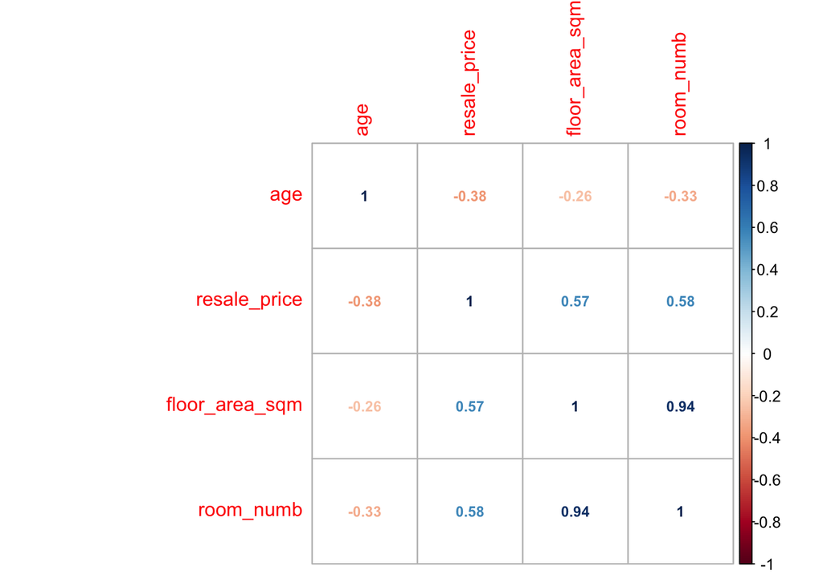

Figure 1.1 The correlation matrix.

```r
dane_c <- scale(dane_c)
matrix <- data.matrix(dane_c, rownames.force = NA)
matrix_2 <- cor(matrix)
corrplot(matrix_2, method = "number", number.cex = 0.75, order="hclust")
```

The variable ‘room_numb’ is strongly correlated with the variable ‘floor_area_sqm’. This method of selecting variables for cluster analysis is often criticized. For most clustering methods, no assumption is made about normal distribution or lack of correlation, so I will leave all variables in the analysis, but I will check if there are outlying observations.

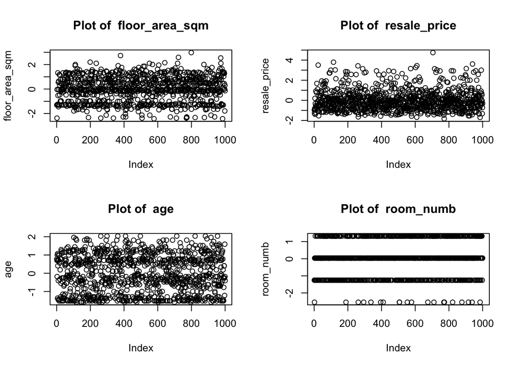

Figure 1.2 Variable analysis.

```r
library(cluster)
library(gridExtra)
par(mfrow=c(2,2))
colnames <- colnames(dane_c)
for (i in colnames) {
  plot(dane_c[,i], main = paste("Plot of ", i), ylab = i)
}
```

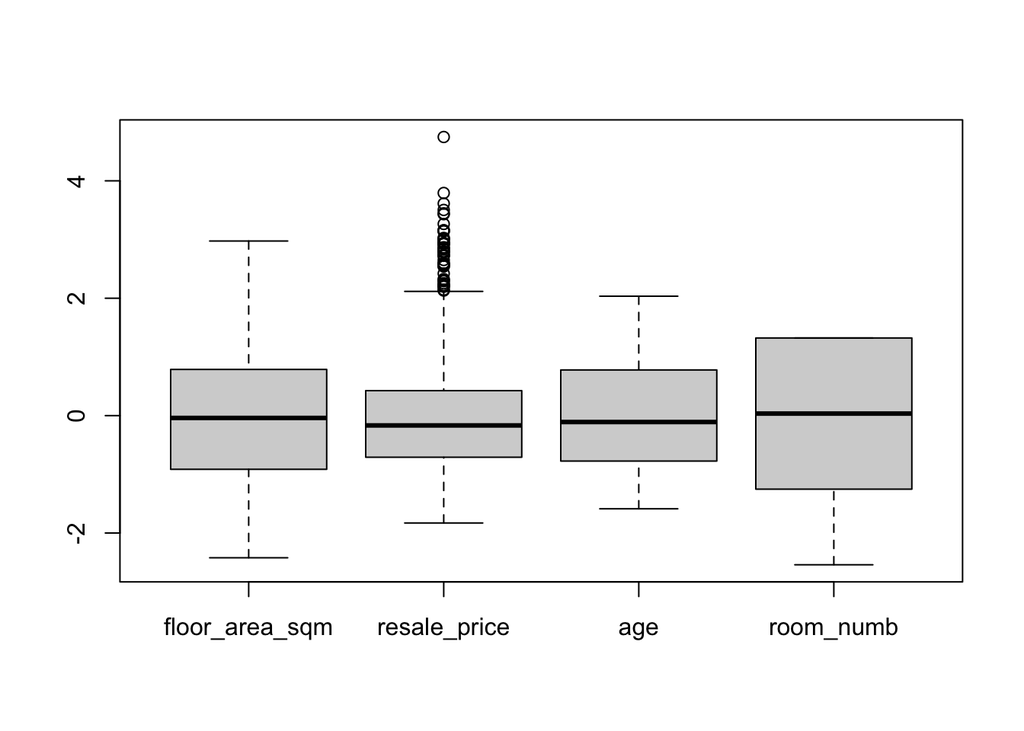

Figure 1.3 Box plot of variables.

```r
boxplot(dane_c) #$out
```

As we can see there are outlying observations. The next step is to remove outliers.

```r
dane_c=as.data.frame(dane_c)
dane = rm.outlier(dane_c, fill = TRUE, median = FALSE, opposite = FALSE)
dane = as.data.frame(dane)
```

# Clustering

The first problem concerns the number of classified objects. As the number of classified objects grows, the number of possible divisions of the set grows. The second problem, which requires the use of appropriate algorithms, is the number of variables describing objects and the distribution of objects in space. In order to choose the best number of clusters, we need the methods and algorithms presented below.

## 2. Choice of distance measure.

First, we have to assign a proper distance measure between data. Then, we look for a partition, where the distance between objects within parition is minimized and distance between objects from different clusters is maximised. [1] I will choose the Manhattan distance which is a suitable measure for the metric scales. It produces similar results to the Euclidean measure, but is more robust to outliers.

```r
distance <- dist(dane, method = "manhattan")
grupy <- agnes(distance, method = "ward")
```

## 3. Determining the number of classes

The number of classes depends on the selected model.

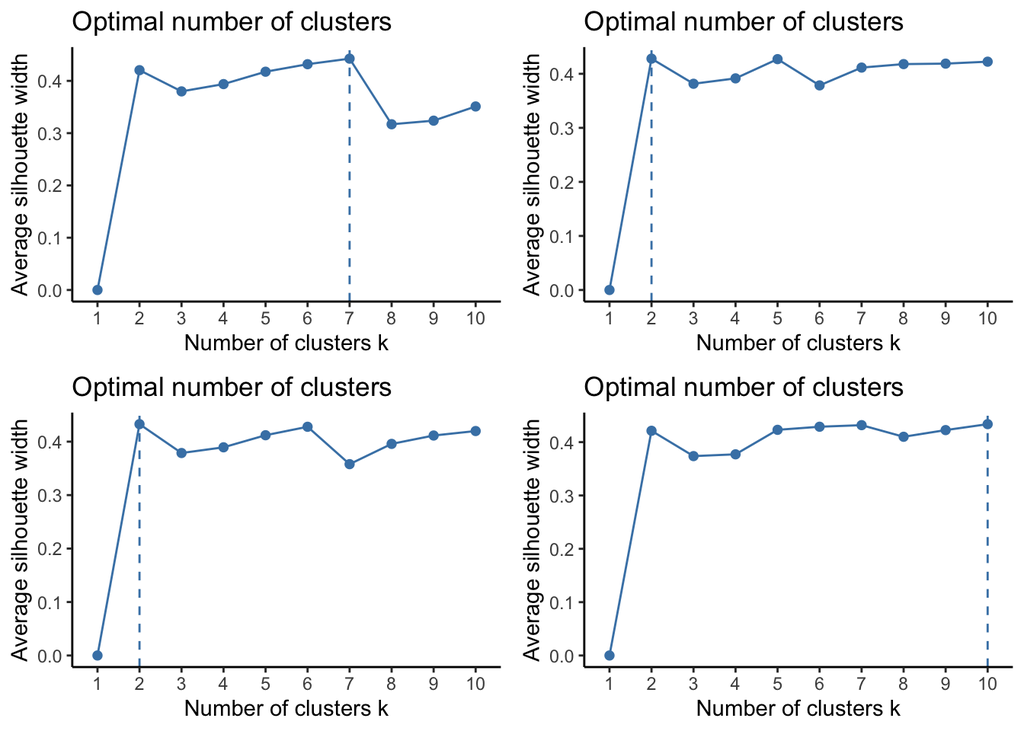

Figure 3.1 Optimal number of clusters for individual models.

```r
p1 <- fviz_nbclust(dane, FUNcluster = kmeans, method = "silhouette") + theme_classic()
p2 <- fviz_nbclust(dane, FUNcluster = cluster::pam, method = "silhouette") + theme_classic()
p3 <- fviz_nbclust(dane, FUNcluster = cluster::clara, method = "silhouette") + theme_classic()
p4 <- fviz_nbclust(dane, FUNcluster = hcut, method = "silhouette") + theme_classic()
grid.arrange(p1, p2, p3, p4, ncol=2)
```

Based on the charts and silhouette statistic, we choose the number of classes equal to 2. This number of classes is indicated by two models and for the other two the ‘Average width’ for the value of 2 is very similar to the one indicated by the given model.

I will evaluate the results of the clustering into two classes.

```r
library(clusterSim)
wyn= replication.Mod(dane, v='m', u=2, centrotypes= "medoids", distance='d1', method='pam')
```

The result is **0.9523348** and it proves the high stability of the division into two classes.

```r
wyn2= replication.Mod(dane, v='m', u=7, centrotypes= "medoids", distance='d1', method='kmeans')
```

In comparison, the stability of the k-means model for the seven classes is **0.7206302** and it is much lower.

## 4.Choice of classification method.

### K-means - flat clustering

In K-Means method, each class is represented by centroids. We are looking for a division of the set for which the covariance matrix for the classes reaches the minimum. This approach employs cluster center (means) to represent cluster. We assign data elements to the closest cluster (center). The centroid’s position is recalculated everytime a component is added to the cluster and this continues until all the components are grouped into the final required number of clusters. The purpose is to minimize the square error of the intra-class dissimilarity. After we assign each object to the cluster with the closest center, we compute the new centers of the clusters. [1]

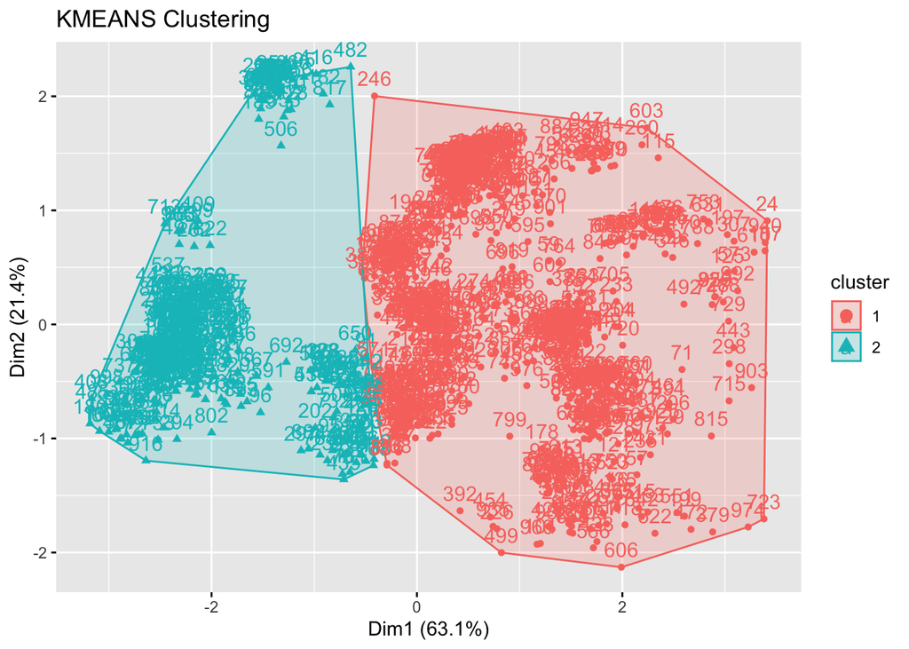

Figure 4.1 K-means clustering.

```r
eclust <- eclust(dane, "kmeans", k.max = 2,  graph = TRUE)
```

### PAM

The algorithm searches for k representative objects in a data set (k medoids) and then assigns each object to the closest medoid in order to create clusters. The goal is to minimize the sum of dissimilarities between the objects in a cluster and the center of the same cluster (medoid). [1]

This method is more robust than k-means in the presence of noise and outliers because a medoids less influenced by outliers or other extreme values than a mean.

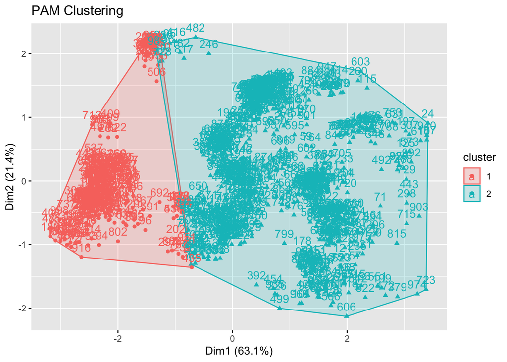

Figure 4.2 PAM clustering.

```r
eclust_2 <- eclust(dane, "pam", k.max = 2, graph = TRUE)
```

### Hierarchical Clustering

The other clustering method method is hierarchical clustering. These methods work with a single procedure and the results can be presented as a dendogram. The classes that are connected to each other are the closest. In this method, each object is assigned to its own cluster; then the algorithm proceeds iteratively, at each stage joining the two most similar clusters, continuing until there is just a single cluster. [1]

### Ward’s dendrogram

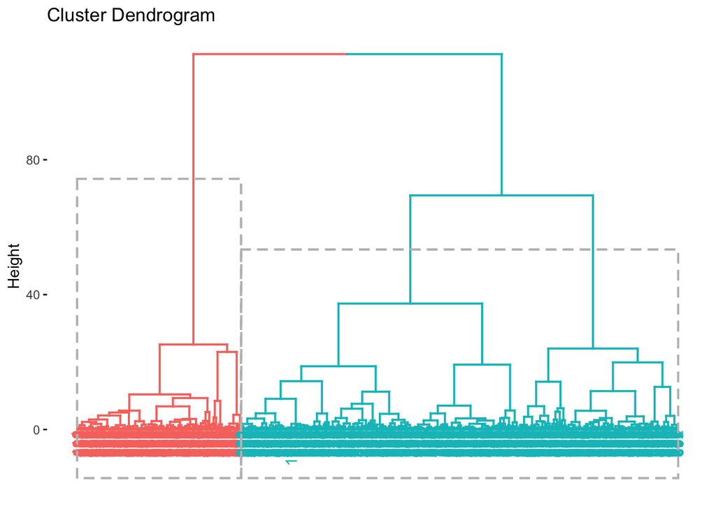

Figure 4.3 Ward’s dendrogram.

```r
fviz_dend(grupy, k = 2, rect = TRUE)
```

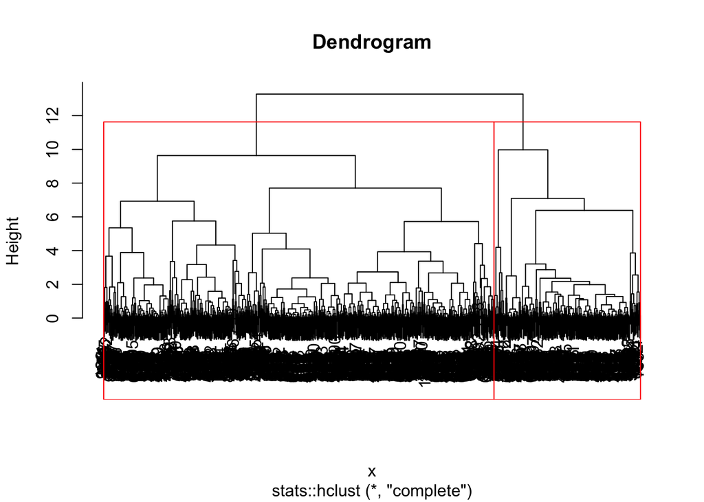

```r
hclust <- eclust(dane, k=2, FUNcluster="hclust", hc_metric="manhattan", hc_method = "complete")
plot(hclust, main = "Dendrogram")
rect.hclust(hclust, k=2, border='red')
```

## 5. Evaluation of the classification results.

The next step will be replication analysis - repetition of classification for another random sample.

We can check it by using ‘replication.Mod’ function, because we can see the parameter S which suggest the the number of simulations.

```r
ocena= replication.Mod(dane, v='m', u=2, centrotypes= "medoids", S=20, distance='d1', method='pam')
```

The result is **0.9637736** and it proves the high stability of the division, after applying multiple re-sampling.

# Conclusions

As a result of the classification we received two classes of apartments. The next step is the interpretation of the obtained results and profiling, which indicates the characteristics of individual classes and allows to determine the differences between them.

## 6. Description and profiling of classes.

As a result we will see three-dimensional array. First dimension contains cluster number. Second dimension contains original coordinate (variable) number from matrix or data set.

Third dimension contains number from 1 to 5:

1.arithmetic mean

2.standard deviation

3.median

4.median absolute deviation (mad)

5.mode - value of the variable which has the largest observed frequency.

```r
cl=pam(dane_2,2)
desc=cluster.Description(dane_2, cl$cluster)
print(desc)
```

```
## , , 1
##
##      [,1]       [,2]          [,3]      [,4]
## [1,] "83.732"   "327702.5952" "29.976"  "3.5896"
## [2,] "105.6972" "535604.1961" "20.1699" "4.4248"
##
## , , 2
##
##      [,1]      [,2]          [,3]      [,4]
## [1,] "19.3681" "53753.8255"  "12.7823" "0.7314"
## [2,] "14.7969" "122173.9358" "12.4271" "0.5532"
##
## , , 3
##
##      [,1]  [,2]     [,3] [,4]
## [1,] "84"  "330000" "33" "4"
## [2,] "105" "492000" "20" "4"
##
## , , 4
##
##      [,1]      [,2]      [,3]      [,4]
## [1,] "25.2042" "63751.8" "13.3434" "1.4826"
## [2,] "17.7912" "85990.8" "17.7912" "0"
##
## , , 5
##
##      [,1] [,2]     [,3] [,4]
## [1,] "67" "370000" "35" "3"
## [2,] "93" "420000" "5"  "4"
```

- floor_area_sqm - first cluster contains of smallest flats -

the average area is 83 square meters. The second group is large apartments.

- resale_price - The average price of flats in the first cluster is much lower than in the second cluster.
- age - Mean age also differs from group to group. The first group includes apartments that are on average older than the second group.
- room_numb - The first group of apartments is characterized by a smaller number of rooms.

# Summary

The clustering analysis was started with the selection of variables (**floor_area_sqm, resale_price, age, room_numb**) and distance measures (**manhattan distance**). Then the number of clusters was determined on model estimates and a measure of model stability. The next step was model selection. Finally, the **PAM model was chosen for analysis**, which gave the most stable results. The last step was to present and describe the characteristics of the specified classes. **Using clustering methods we received two types of apartments**. Classes consist of such elements, which are closest to each other inside the class and different from apartments in the second class. First class apartments are smaller and cheaper, as opposed to second class apartments.

Sources:

1.*Katarzyna Kopczewska, Jacek Lewkowicz. Unsupervised Learning. Presentation from the classes.*

2.*Statystyczna Analiza Danych z wykorzystaniem programu R. Marek Walesiak. 2012. PWN.*

3.*https://www.atsjournals.org/doi/full/10.1164/rccm.200711-1754OC - Cluster Analysis and Clinical Asthma Phenotypes. Pranab Haldar.*

4.*https://cran.r-project.org/web/packages/clusterSim/clusterSim.pdf*